# Um bom negócio ?

António Cruz

2017-01-06

Vamos supor que você pretende comprar um carro usado. O que faz?

Bem, presumo que das primeiras coisas é consultar algum site de compra e venda de carros usados e procurar algum carro com as características que considera relevantes de forma a ter uma ideia das alternativas e preços. Provavelmente até visitará algum stand recomendado por um amigo seu ou que fica perto da sua casa ou trabalho.

Mas, qual a melhor compra que pode fazer?

E se que quiser vender o meu carro? qual o preço que devo pedir?

Dependendo dos seus objetivos, se é comprar ou vender, se já escolheu a marca e modelo ou se apenas tem um limite de valor, se privilegia o preço, a idade os kms, todas estas questões vão influenciar a sua decisão final e eventualmente gerar alternativas demasiado numerosas que me permitam focar apenas nas propostas mais interessantes.

**Enquadramento e pressupostos**

Embora este seja um exercicio académico no sentido que coloco questões que certamente seriam diferentes das colocadas por alguém que efetivamente quisesse comprar um carro, os dados são reais e as questões colocadas parecem-me suficientemente práticas para terem valor.

Para simplificar vou considerar alguns pressupostos, que foram logo considerados na pesquisa e recolha das potenciais viaturas:

- Quero um carro a gasóleo
- Pretendo um carro que tenha mais de 20 000kms e menos de 200 000 kms.
- Não quero gastar mais de 15 000€ e só considero carros a partir de 4 000€ (quero um carro *jeitosito*)
- Não tenho preferência por marca ou modelo

**Recolha de dados**

Como em todos os processos de decisão, é necessário obter alguma informação prévia para podermos tomar uma decisão informada.

Em conformidade pesquisei informação sobre viaturas usadas em dois sites de referência em Portugal selecionei viaturas que cumpriam os meus pressupostos.

Isso resultou na recolha de dados acerca de 12462 viaturas. No entanto, foi necessário fazer algum trabalho de transformação de dados de forma a ter dados estandartizados e devidamente preparados para análise. Entre estas transformações estão a eliminação de viaturas muito antigas, marcas com poucas viaturas, normalização de nomes, etc.

Depois de efetuadas as referidas transformações, ficamos com a informação de 8869 viaturas, uma redução de 28.8%, sendo que 3284 viaturas foram recolhidas do **site1** e 5585 do **site2**.

É claro que estamos a simplificar e tratar uma viatura de dezembro da mesma forma que tratamos outra do mesmo ano, mas de janeiro. É uma questão de simplificação, mas poderíamos facilmente tratarmos em meses em vez de anos, caso tivéssemos nos nossos dados o mês de matricula (por acaso temos para um dos sites mas não para o outro).

**Análise exploratória**

Temos um conjunto de 8869 viaturas que são caracterizadas por 10 variáveis.

Para termos uma ideia mais concreta da informação disponnivel podem analisar o quadro seguinte com 20 registos selecionados de forma aleatória.

[interactive chart not shown]

**Por marca**

Podemos verificar que a maioria das viaturas que fazem parte da nossa amostra são da marca **Renault** e representam 24.6%.

[interactive chart not shown]

Não é de mais destacar que nós temos misturadas viaturas sedan, compactas, de serviço e carrinhas de diferentes modelos na amostra e que esse facto tem obviamente impacto nas análises e conclusões que tiramos.

Apesar de termos retirado da amostra as marcas com poucas viaturas, temos modelos dentro das marcas que possuem muito poucas viaturas. Para percebermos melhor esse fenómeno, apresentamos a *treemap* seguinte onde poderão com o cursor em cima do conjunto de modelos de uma marca, clicar e ver apenas os modelos dessa marca.

[interactive chart not shown]

A *peugeot* é a marca com mais modelo (20), seguida da *fiat* (18) e da *citroen* (15).

**Relação entre o Preço e idade**

E relativamente à idade? qual o valor que cada marca perde a cada ano que passa?

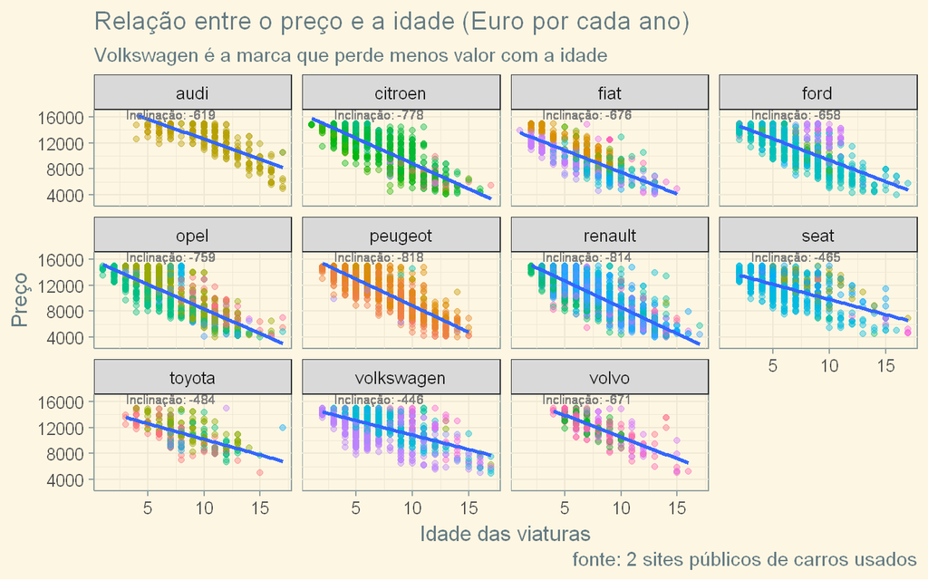

Como podem reparar, algumas marcas, com destaque para a *Audi* e *Volvo*, não tem na nossa amostra viaturas muito novas, enquanto outras tem viaturas muto novas como é o caso da *Opel*. Tal facto deve-se, penso eu, por termos limitado o valor a 15000€ e com poucos anos o valor das viaturas usadas quer da *Audi* como da *Volvo* ultrapassam o limite que fixamos.

No entanto é interessante verificar que com base nos nossos dados, as viaturas que menos valor perdem com o passar dos anos são a *Volkswagen*, *Toyota* e a *Seat* (uma surpresa), aprsentando uma desvalorização inferior a 500€ por ano.

No lado oposto as marcas que perdem mais valor com o passar do tempo é a *Peugeot* e a *Renault*, cujas viaturas desvalorizão mais de 800€ a cada ano que passa.

**Correlações**

Podemos tentar perceber outras correlações, nomeadamente entre as variáveis quantitativas:

[interactive chart not shown]

Confirmando as analises anteriores, temos que o preço se correlaciona negativamente com os kms realizados e a idade, embora essa correlação seja mais forte com a idade (-0.72 versus -0.41), i.e., é mais importante a idade que os kms no preço de venda.

Mas temos uma descoberta que é contrária ao censo comum: o preço correlaciona-se positivamente com a média dos kms anuais, i.e., as viaturas que fazem mais kms por ano tem preços mais elevados.

Se repararmos, a média dos kms por ano correlaciona-se negativamente com a idade e essa pode ser a razão que explica esta estranha descoberta: os carros mais novos são mais utilizados e fazem em média mais kms e quando vão ficando mais velhos a sua utilização vai diminuindo. Parece ser uma explicação razoável e que faz sentido.

**Questões finais**

Não diria que foi uma análise exaustiva, mas foi longa e espero que a tenham lido até ao fim.

Julgo que conseguimos perceber coisas interessantes a compreender melhor a estrutura e distribuição dos dados, conhecimento que será bastante útil para a 2ª parte deste trabalho, parte essa onde iremos construir alguns modelos e realizar algumas simulações que nos ajudem a responder a questões concretas que irei colocar.

Vemo-nos na parte 2 deste exemplo.